# xv20220623_3_interactions_data

# Figure 3D-H: Plot cosine distance tiles

(D-H) CCD similarity score matrix of proteins in ATM clique (D), FA clique (E), mixed clique (F), ATM sig-naling (G) and DNAPKcs KO and inhibition (H).

### Data processing

```r
#Select genes in cliques
cosine.cliques.dcast <- significant_proteins %>% filter(gene %in% all_cliques$gene) %>% reshape2::dcast(chrom_feature ~ gene, value.var = "CCD_synergy_score") %>% column_to_rownames(var = "chrom_feature")

#Generate cosine distance matrix
cosine.d.cliques <- cosine(as.matrix(cosine.cliques.dcast)) %>% reshape2::melt()
```

### Data ploting

#### Figure 3D: ATM clique I

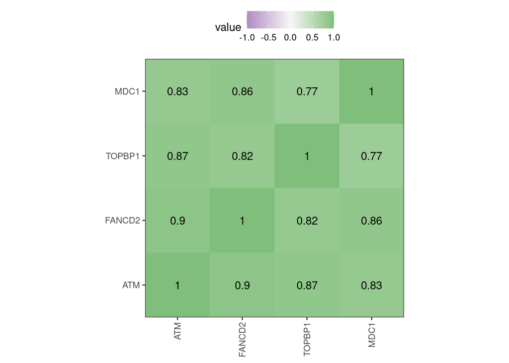

```r
#Clique 1
ggplot(cosine.d.cliques %>% filter(Var1 %in% c("ATM","FANCD2","TOPBP1","MDC1") & Var2 %in% c("ATM","FANCD2","TOPBP1","MDC1"))) +
     geom_tile(aes(fct_relevel(Var1,c("ATM","FANCD2","TOPBP1","MDC1")), fct_relevel(Var2,c("ATM","FANCD2","TOPBP1","MDC1")), fill = value))+
     theme_bw() + theme(axis.text.x = element_text(angle = 90, vjust = 0.5, hjust = 1), legend.position = "top") +
     coord_fixed(expand = F,ratio = 1) + scale_fill_gradient2(low = "#af8dc3", mid = "#f7f7f7", high = "#7fbf7b", limits = c(-1,1)) +
     geom_text(aes(fct_relevel(Var1,c("ATM","FANCD2","TOPBP1","MDC1")), fct_relevel(Var2,c("ATM","FANCD2","TOPBP1","MDC1")),label = round(value, digits = 2))) + theme(axis.title = element_blank())
```

#### Figure 3E: FA clique I

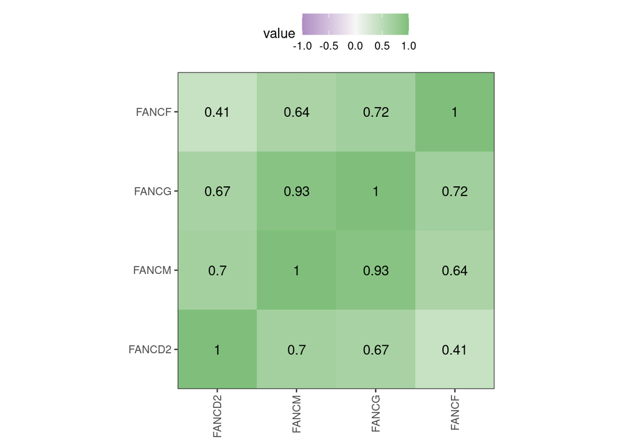

```r
#Clique 3
ggplot(cosine.d.cliques %>% filter(Var1 %in% c("FANCD2","FANCM","FANCG","FANCF") & Var2 %in% c("FANCD2","FANCM","FANCG","FANCF"))) +
     geom_tile(aes(fct_relevel(Var1,c("FANCD2","FANCM","FANCG","FANCF")), fct_relevel(Var2,c("FANCD2","FANCM","FANCG","FANCF")), fill = value))+
     theme_bw() + theme(axis.text.x = element_text(angle = 90, vjust = 0.5, hjust = 1), legend.position = "top") +
     coord_fixed(expand = F,ratio = 1) + scale_fill_gradient2(low = "#af8dc3", mid = "#f7f7f7", high = "#7fbf7b", limits = c(-1,1)) +
     geom_text(aes(fct_relevel(Var1,c("FANCD2","FANCM","FANCG","FANCF")), fct_relevel(Var2,c("FANCD2","FANCM","FANCG","FANCF")),label = round(value, digits = 2))) + theme(axis.title = element_blank())
```

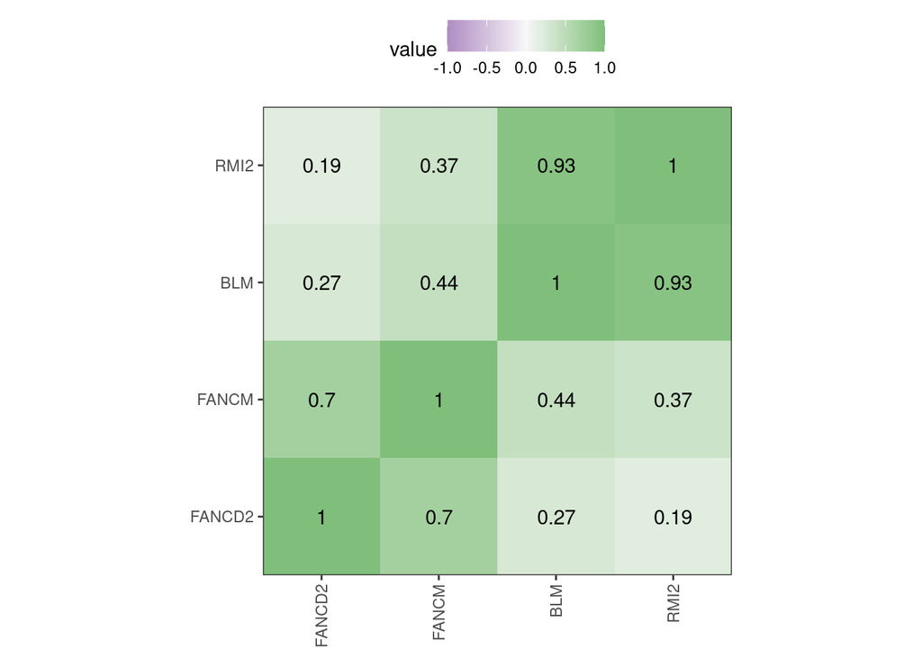

```r
#Clique 4
ggplot(cosine.d.cliques %>% filter(Var1 %in% c("FANCD2","FANCM","BLM","RMI2") & Var2 %in% c("FANCD2","FANCM","BLM","RMI2"))) +
     geom_tile(aes(fct_relevel(Var1,c("FANCD2","FANCM","BLM","RMI2")), fct_relevel(Var2,c("FANCD2","FANCM","BLM","RMI2")), fill = value))+
     theme_bw() + theme(axis.text.x = element_text(angle = 90, vjust = 0.5, hjust = 1), legend.position = "top") +
     coord_fixed(expand = F,ratio = 1) + scale_fill_gradient2(low = "#af8dc3", mid = "#f7f7f7", high = "#7fbf7b", limits = c(-1,1)) +
     geom_text(aes(fct_relevel(Var1,c("FANCD2","FANCM","BLM","RMI2")), fct_relevel(Var2,c("FANCD2","FANCM","BLM","RMI2")),label = round(value, digits = 2))) + theme(axis.title = element_blank())
```

```r
#Import interesting genes
cosine.highlights.genes <- table_S3_CCDs %>% filter(gene %in% c("ATM", "CHEK2","PRKDC")) %>% na.omit()
#Import inhibitor data
cosine.highlights.drugs <- CCD_inhibitors_data %>% filter(drug %in% c("ATMi", "DNAPKi")) %>% dplyr::select(gene = drug, chrom_feature,CCD_synergy_score)
#Bind all data
cosine.highlights.all <- bind_rows(cosine.highlights.genes, cosine.highlights.drugs)

#dcast
cosine.highlights.dcast <- cosine.highlights.all %>% reshape2::dcast(chrom_feature ~ gene, value.var = "CCD_synergy_score") %>% column_to_rownames(var = "chrom_feature")

#Cosine distance
cosine.d.highlingts <- cosine(as.matrix(cosine.highlights.dcast)) %>% melt()
```

#Conclusion: Cosine matrices were properly calculated

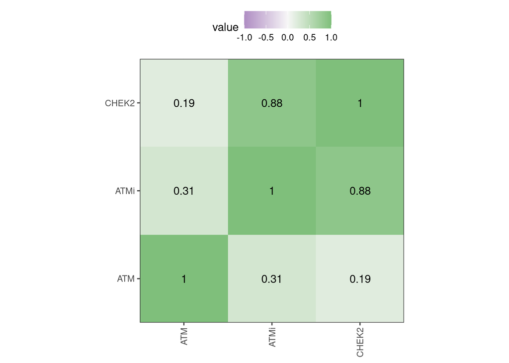

```r
#F: ATM signaling
ATM_order <- c("ATM","ATMi","CHEK2")
ggplot(cosine.d.highlingts %>% filter(Var1 %in% ATM_order & Var2 %in% ATM_order)) +
  geom_tile(aes(fct_relevel(Var1,ATM_order), fct_relevel(Var2,ATM_order), fill = value)) + theme_bw() + theme(axis.text.x = element_text(angle = 90, vjust = 0.5, hjust = 1), legend.position = "top") + coord_fixed(expand = F,ratio = 1) + scale_fill_gradient2(low = "#af8dc3", mid = "#f7f7f7", high = "#7fbf7b", limits = c(-1,1))  + geom_text(aes(fct_relevel(Var1,ATM_order), fct_relevel(Var2,ATM_order),label = round(value, digits = 2))) + theme(axis.title = element_blank())
```

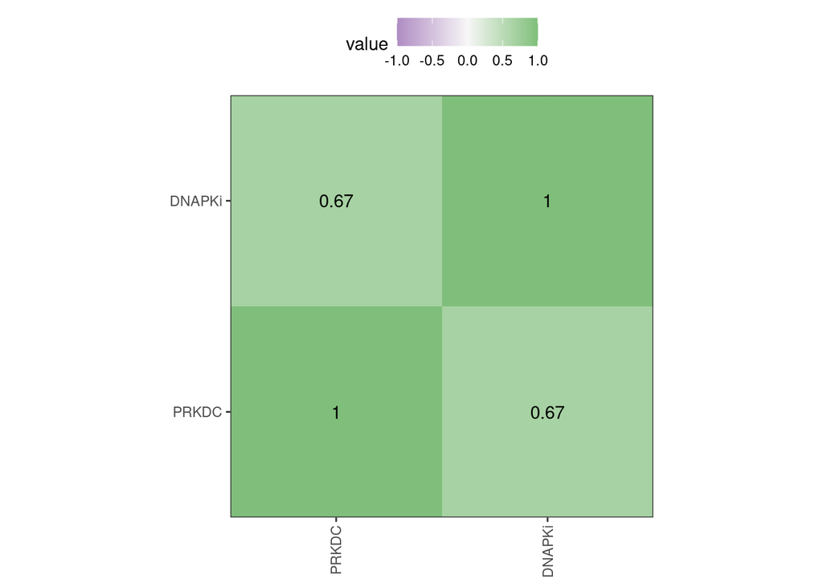

```r
#DNAPK complex
ggplot(cosine.d.highlingts %>% filter(Var1 %in% c("PRKDC","DNAPKi") & Var2 %in% c("PRKDC","DNAPKi"))) +
  geom_tile(aes(fct_relevel(Var1,c("PRKDC","DNAPKi")), fct_relevel(Var2,c("PRKDC","DNAPKi")), fill = value)) + theme_bw() + theme(axis.text.x = element_text(angle = 90, vjust = 0.5, hjust = 1), legend.position = "top") + coord_fixed(expand = F,ratio = 1) + scale_fill_gradient2(low = "#af8dc3", mid = "#f7f7f7", high = "#7fbf7b", limits = c(-1,1)) + geom_text(aes(fct_relevel(Var1,c("PRKDC","DNAPKi")), fct_relevel(Var2,c("PRKDC","DNAPKi")),label = round(value, digits = 2))) + theme(axis.title = element_blank())
```

#Figure 3I-M

I-M) M- and N-synergies discussed in the text. Column labels are names of proteins or the inhibitor used (‘i’ suffix). Proteins or inhibitors with significant CCDs (FDRCCD < 0.05) are marked with an asterisk. Chromatin features are colored as in Fig. 1C. (I) ATM signaling. (J) Fanconi anemia complex. (K) SMC5/6 complex. (L) DNAPKcs KO and inhibition. (M) BRCA1-A complex.

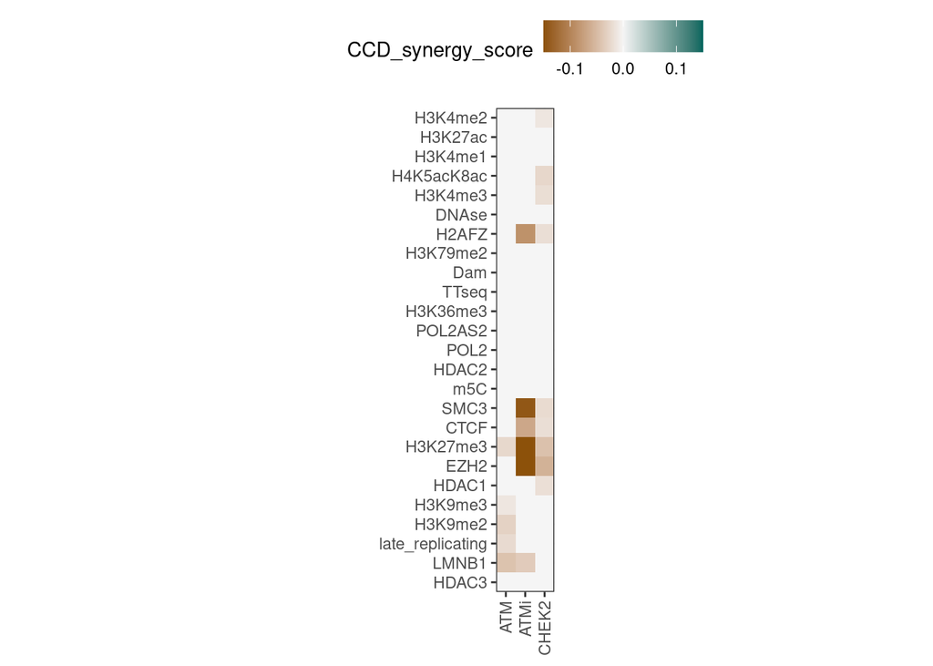

```r
#dcast epistatic interactions (PARP proteins)
ATM.proteins.CCD <- table_S3_CCDs %>% filter(gene %in% c("ATM", "CHEK2"))

#dcast epistatic interactions (PARP inhibitors)
ATM_inhibitors <- CCD_inhibitors_data %>% filter(drug %in% c("ATMi"))


#Cosine distance between all of them
#Prepare for binding
ATM.inhibitor.sel <- ATM_inhibitors %>% dplyr::select(gene = drug, chrom_feature, CCD_synergy_score)
ATM.combined <- ATM.proteins.CCD %>% dplyr::select(gene, chrom_feature, CCD_synergy_score) %>% bind_rows(ATM.inhibitor.sel)
ATM.dcast <- ATM.combined %>% reshape2::dcast(chrom_feature ~ gene, value.var = "CCD_synergy_score") %>% column_to_rownames(var = "chrom_feature")
cosine.d.ATM<- cosine(as.matrix(ATM.dcast))

#PARP combined heatmap
ggplot(ATM.combined) +
  geom_tile(aes(fct_relevel(gene, c("ATM","ATMi","CHEK2")), fct_relevel(chrom_feature,heatmap.chromatin.order), fill = CCD_synergy_score)) +
  scale_fill_gradient2(low = "#8c510a" ,mid = "#f5f5f5", high = "#01665e", breaks = c(-0.1,0, 0.1), limits = c(-0.15,0.15), oob = squish)  +
  coord_fixed(expand = F) + theme_bw() + theme(axis.text.x = element_text(angle = 90, hjust = 1, vjust = 0.5), axis.title = element_blank(), legend.position = "top")
```

#Figure 4B: FA complex

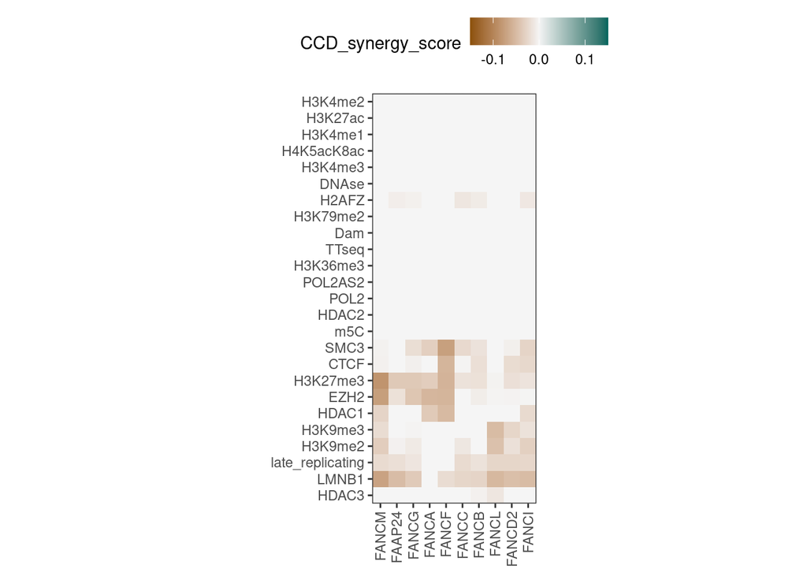

```r
#FA proteins order
FA_prots <- c("FANCM","FAAP24","FANCG","FANCA","FANCF","FANCC","FANCB","FANCL","FANCD2","FANCI")

# Filter FANC proteins
FA.proteins.CCD <- table_S3_CCDs %>% filter(gene %in% FA_prots)

# dCast FANC proteins
FA.proteins.dcast <- FA.proteins.CCD %>% reshape2::dcast(gene ~ chrom_feature, value.var = "CCD_synergy_score") %>% column_to_rownames(var = "gene")

#Cosine distance between all of them
cosine.d.FANC <- cosine(as.matrix(t(FA.proteins.dcast)))

#Plot heatmap
ggplot(FA.proteins.CCD) +
  geom_tile(aes(fct_relevel(gene,FA_prots), fct_relevel(chrom_feature,heatmap.chromatin.order), fill = CCD_synergy_score)) +
  scale_fill_gradient2(low = "#8c510a" ,mid = "#f5f5f5", high = "#01665e",  breaks = c(-0.1,0, 0.1), limits = c(-0.15,0.15))  +
  coord_fixed(expand = F) + theme_bw() + theme(axis.text.x = element_text(angle = 90, hjust = 1, vjust = 0.5), axis.title = element_blank(), legend.position = "top")
```

#Figure 4C: SMC5/6 complex

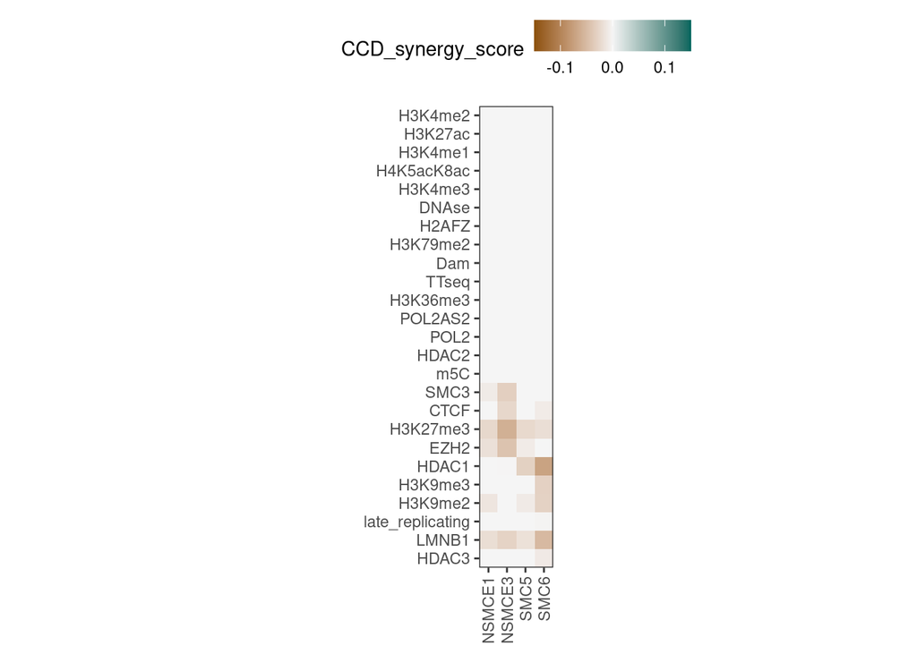

```r
#dcast epistatic interactions (PARP proteins)
SMC5_compl <- table_S3_CCDs %>% filter(gene %in% c("SMC5","NSMCE1","NSMCE3","NSMCE2","NSMCE4","SMC6")) %>% na.omit()

SMC5.dcast <- SMC5_compl %>% reshape2::dcast(chrom_feature ~ gene, value.var = "CCD_synergy_score") %>% column_to_rownames(var = "chrom_feature")
cosine.d.SMC5<- cosine(as.matrix(SMC5.dcast))

#PARP combined heatmap
ggplot(SMC5_compl) +
  geom_tile(aes(fct_relevel(gene,c("NSMCE1","NSMCE3","SMC5","SMC6")), fct_relevel(chrom_feature,heatmap.chromatin.order), fill = CCD_synergy_score)) +
  scale_fill_gradient2(low = "#8c510a" ,mid = "#f5f5f5", high = "#01665e", breaks = c(-0.1,0, 0.1), limits = c(-0.15,0.15), oob = squish)  +
  coord_fixed(expand = F) + theme_bw() + theme(axis.text.x = element_text(angle = 90, hjust = 1, vjust = 0.5), axis.title = element_blank(), legend.position = "top")
```

# Figure 4D: DNAPKi

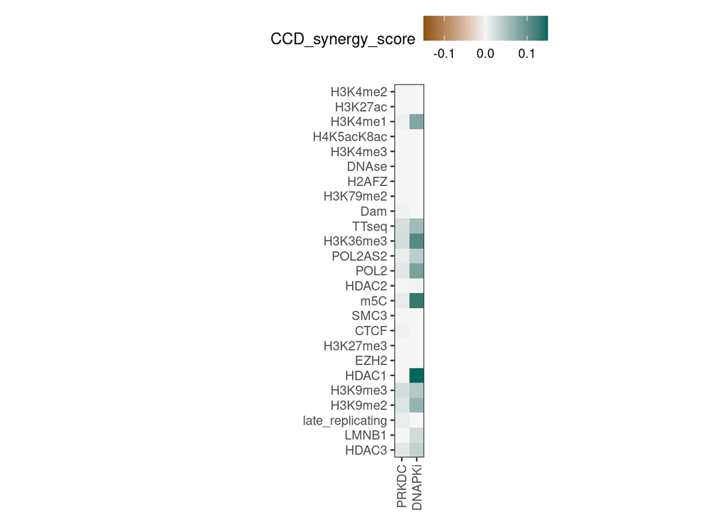

```r
#dcast epistatic interactions (PARP proteins)
DNAPK.proteins.CCD <- table_S3_CCDs %>% filter(gene == "PRKDC") %>% dplyr::select(gene, chrom_feature, CCD_synergy_score)
DNAPK.inhibitors <- CCD_inhibitors_data %>% filter(drug == "DNAPKi") %>% dplyr::select(gene = drug, chrom_feature, CCD_synergy_score)

# Bind rows
DNAPK.perturbations <- bind_rows(DNAPK.proteins.CCD, DNAPK.inhibitors)

# DNAPK inhibition
ggplot(DNAPK.perturbations) +
    geom_tile(aes(fct_relevel(gene, c("PRKDC","DNAPKi")), fct_relevel(chrom_feature,heatmap.chromatin.order), fill = CCD_synergy_score)) +
    scale_fill_gradient2(low = "#8c510a" ,mid = "#f5f5f5", high = "#01665e",limits = c(-0.15,0.15), breaks = c(-0.1,0, 0.1), oob = squish)  +
    coord_fixed(expand = F) + theme_bw() + theme(axis.text.x = element_text(angle = 90, hjust = 1, vjust = 0.5), axis.title = element_blank(), legend.position = "top")
```

# Figure 4E: BRCA1-A complex

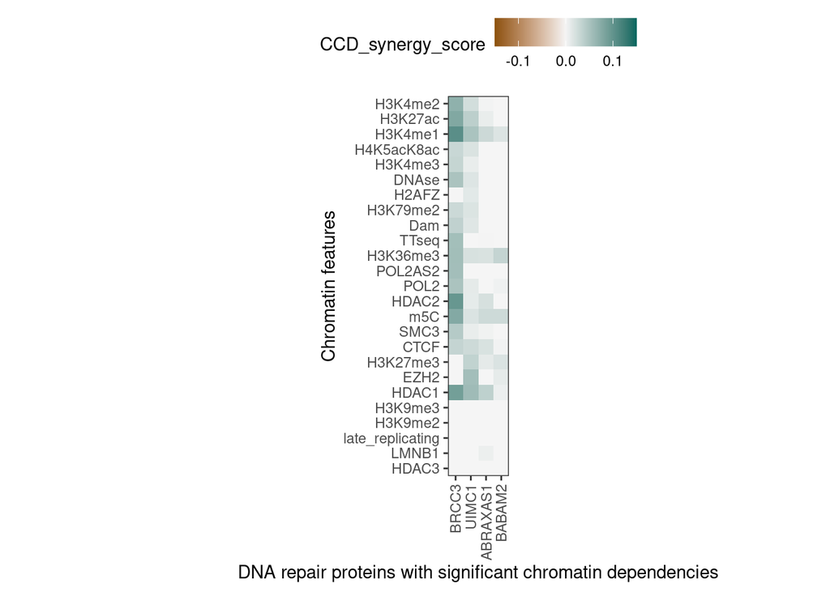

```r
#BRC1A complex proteins
BRCA1A_complex <- c("BRCC3","UIMC1","ABRAXAS1","BABAM2")

# Separate data based on the significant IPRs that they have (based on z-score)
UIMC1_BRCC3<- table_S3_CCDs %>% filter(gene %in% BRCA1A_complex)  %>% na.omit()

# heatmap: All heatmaps together
ggplot(UIMC1_BRCC3) +
  geom_tile(aes(fct_relevel(gene, BRCA1A_complex),fct_relevel(chrom_feature, heatmap.chromatin.order), fill = CCD_synergy_score)) +
  scale_fill_gradient2( low = "#8c510a",mid = "#f5f5f5", high = "#01665e",limits = c(-0.15,0.15), oob = squish, breaks = c(-0.1,0,0.1)) + theme_bw() + theme(axis.text.x = element_text(angle = 90, vjust = 0.5, hjust = 1), legend.position = "top") + coord_fixed(expand = F,ratio = 1) + xlab("DNA repair proteins with significant chromatin dependencies") + ylab("Chromatin features")
```

#Export Table S8 #This table includes the protein pairs that interact with each other.

```r
setwd(in.dir)
#Prepare the file to export
export_protein_protein_table <- ddr.ccd.physical.biogrid.rep.db %>% left_join(melt.dist.matrix)
#Table S4
write.xlsx(export_protein_protein_table, file = "data/supplementary_tables/xv20220913_Table_S8_BioGRID_interaction_CCD.xlsx")
```